# InVivoStat Equivalence TOST Test Analysis

## Response and equivalence bounds

The Resp11 response is currently being analysed by the Equivalence (TOST) test Analysis module.

The lower equivalence bound is defined as 10.00 and the upper equivalence bound is defined as 20.00. As both boundaries are defined a two one-sided (TOST) equivalence test has been performed.

## Scatterplot of the observed data

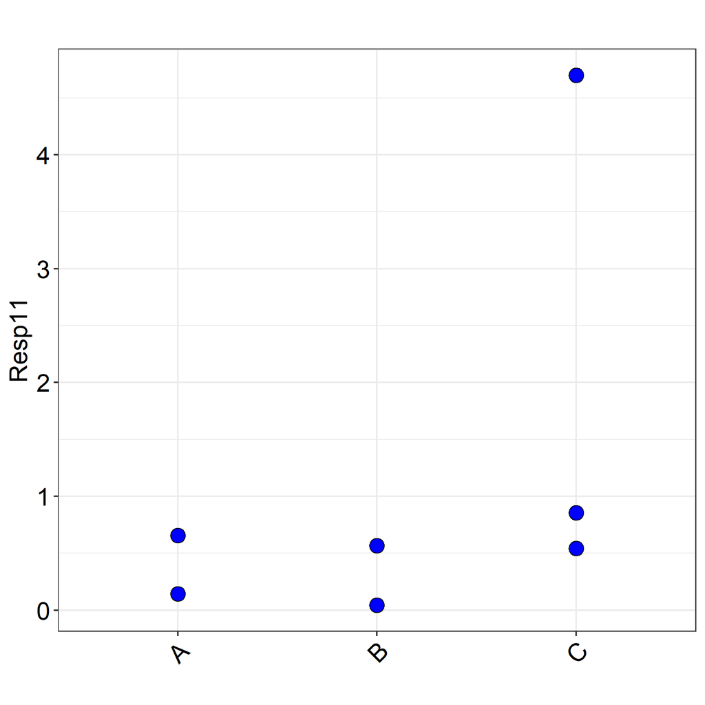

Tip: Use this plot to identify possible outliers.

## Warning

Unfortunately the residual degrees of freedom are low (less than 5). This may make the estimation of the underlying variability, and hence the results of the statistical tests, unreliable. This can be caused by attempting to fit too many factors, and their interactions, in the statistical model. Where appropriate we recommend you fit some of the 'Treatment' factors as 'Other design' factors. This will remove their interactions from the statistical model and therefore increase the residual degrees of freedom.

## Model coefficients

|  | Estimate | Std. Error | t-value | p-value |
| --- | --- | --- | --- | --- |
| (Intercept) | 0.9120 | 0.6380 | 1.43 | 0.2260 |
| Treat141 | -0.5137 | 0.9300 | -0.55 | 0.6101 |
| Treat142 | -0.6067 | 0.9300 | -0.65 | 0.5497 |

## All pairwise equivalence assessments

| Comparison | Difference | Lower one-sided 95% CI | Upper one-sided 95% CI | Lower equivalence bound | Upper equivalence bound | Equivalence assessment |
| --- | --- | --- | --- | --- | --- | --- |
| A - B | 0.093 | -3.440 | 3.626 | 10 | 20 | Not equivalent |
| A - C | -1.634 | -4.860 | 1.591 | 10 | 20 | Not equivalent |
| B - C | -1.727 | -4.953 | 1.498 | 10 | 20 | Not equivalent |

## Plot of the comparisons between the predicted means with 95% one-sided confidence intervals along with equivalence bounds

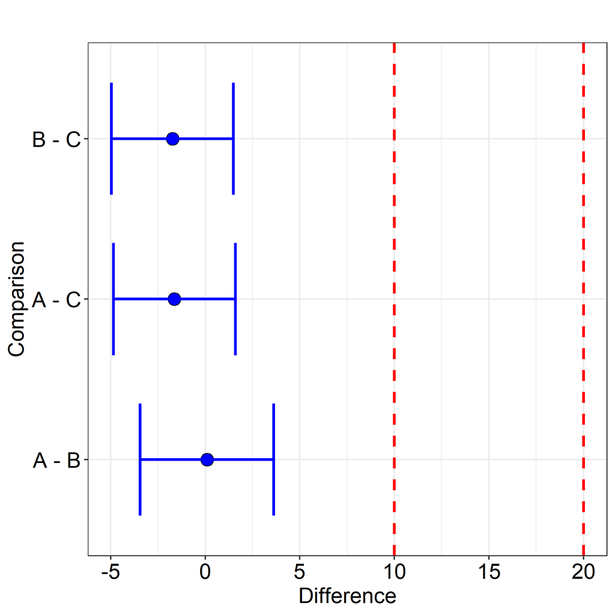

## Conclusion

Conclusion: There are no equivalent means.

## Diagnostic plot

### Residuals vs. predicted plot

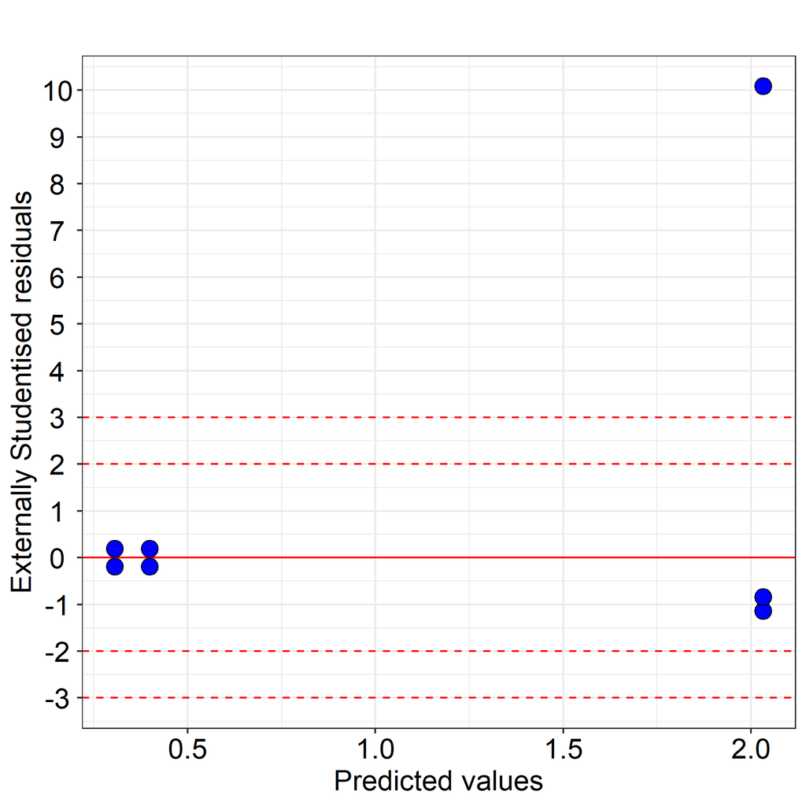

Tip: On this plot look to see if the spread of the points increases as the predicted values increase. If so the response may need transforming.

Tip: Any observation with a residual less than -3 or greater than 3 (SD) should be investigated as a possible outlier.

## Analysis description

The data were analysed using a Two One-Sided (TOST) equivalence test, see Limentani et al. 2005, with Treat14 as the treatment factor.

For more information on the theoretical approaches that are implemented within this module, see Bate and Clark (2014).

## References

When referring to InVivoStat, please cite 'InVivoStat, version 5.2.0'.

Bate, S.T. and Clark, R.A. (2014). The Design and Statistical Analysis of Animal Experiments. Cambridge University Press.

Limentani, G.B., Ringo, M.C., Ye, F., Bergquist, M.L. and MCSorley E.O. (2005). Beyond the t-test: Statistical equivalence testing. Analytical Chemistry, 77(11), 221-226.